# R Notebook

#Comparison of two chromatograms of two separate runs of the same sample in FPLC for a protein purification step

#Purpose: Corresponding fractions were mixed together so making sure they are as close to identical as possible

#Data files were too large to read. So data used is a subset of the data exported from the instrument (only the data necessary to graph is included in the file)

#First plot the data for the first. Already have tidyverse, which includes ggplot (can also edit size of line)

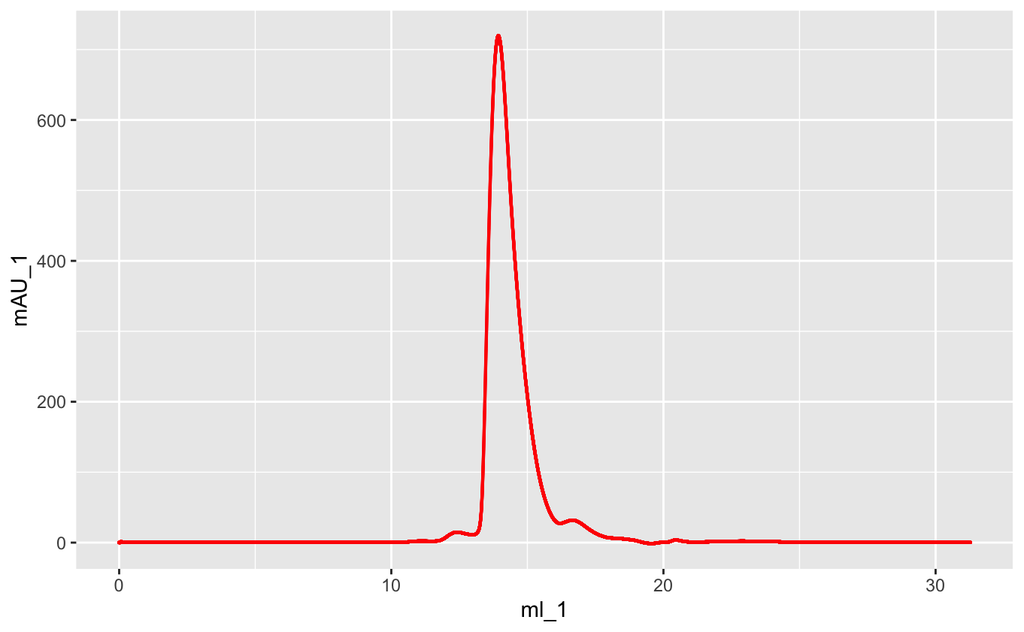

```r
library(ggplot2)
ggplot(data = Superdex200_Run1and2_Subset,
       mapping = aes (x = ml_1,
                      y = mAU_1))+
  geom_point(size = .1, color = "red")
```

#then create second plot in the same way

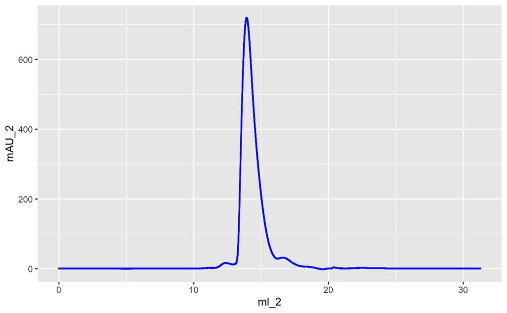

```r
ggplot(data = Superdex200_Run1and2_Subset,
      mapping = aes (x = ml_2,
                      y = mAU_2))+
  geom_point(size = .1, color = "blue")
```

#downloaded cowplot and magick

```r
library(ggplot2)
library(cowplot)
```

#The goal is to combine them but since they dont have the same x or y axis then they can be combined as images

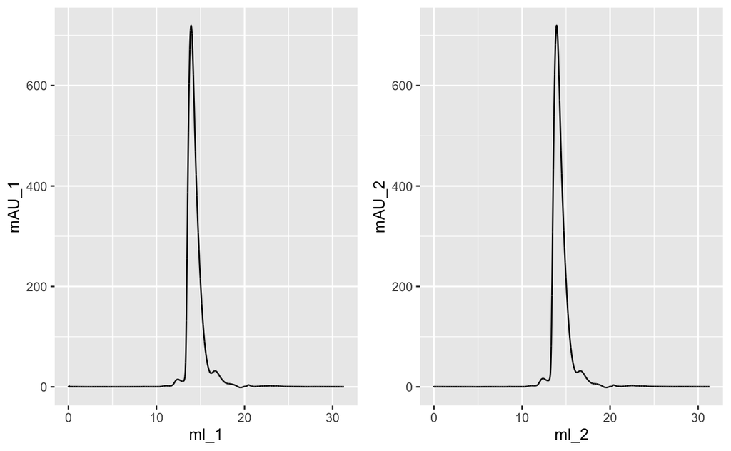

```r
p1 <- ggplot() +
  geom_line(data=Superdex200_Run1and2_Subset, aes(x = ml_1,
                      y = mAU_1))
ggsave(filename = 'plot1.png', device = 'png', bg = 'transparent')
p2 <- ggplot() +
  geom_line(data=Superdex200_Run1and2_Subset, aes(x = ml_2,
                      y = mAU_2))
ggsave(filename = 'plot2.png', device = 'png', bg = 'transparent')
cowplot::plot_grid(p1, p2, nrow = 1)
```

#Combine images of plots by morphing to make animation

```r
library(magick)
plot1 <- image_scale(image_read("plot1.png"))
plot2 <- image_scale(image_read("plot2.png"))
image_resize(c(plot1, plot2), '550x400!') %>%
  image_background('white') %>%
  image_morph() %>%
  image_animate(optimize = TRUE)
```

| format | width | height | colorspace | matte | filesize | density |
| --- | --- | --- | --- | --- | --- | --- |
| gif | 550 | 400 | sRGB | TRUE | 0 | 118x118 |
| gif | 540 | 392 | sRGB | TRUE | 0 | 118x118 |
| gif | 540 | 392 | sRGB | TRUE | 0 | 118x118 |
| gif | 540 | 392 | sRGB | TRUE | 0 | 118x118 |
| gif | 540 | 392 | sRGB | TRUE | 0 | 118x118 |
| gif | 540 | 393 | sRGB | TRUE | 0 | 118x118 |
| gif | 540 | 392 | sRGB | TRUE | 0 | 118x118 |
| gif | 540 | 392 | sRGB | TRUE | 0 | 118x118 |
| gif | 540 | 392 | sRGB | TRUE | 0 | 118x118 |
| gif | 540 | 392 | sRGB | TRUE | 0 | 118x118 |